# Curs d’introducció a R

# Tests d’hipòtesi

## Exemple 1

Tenim una pastilla per baixar el colesterol i un placebo, volem demostrar que la pastilla funciona i per tant hem de demostrar que els nivells de colesterol del grup que han pres la pastilla són significativamet més baixos que els que no han pres la pastilla.

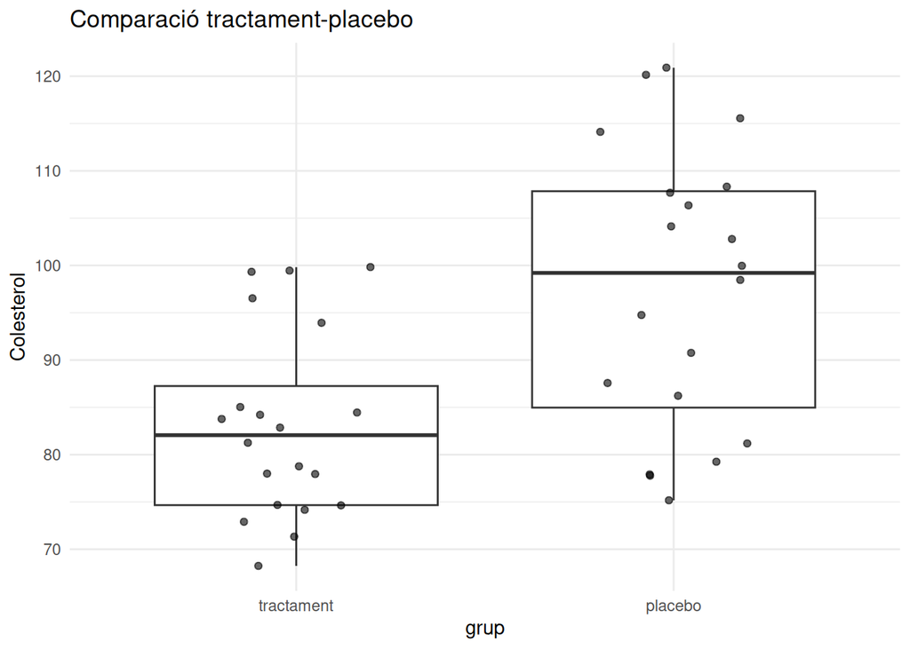

```r
# Simulem les dades:
colesterol <- c(rnorm(20, mean = 85, sd = 10), rnorm(20, mean = 95, sd = 14))
grup <- c(rep("tractament", 20), rep("placebo", 20))

tibble(
  colesterol = as.numeric(colesterol),
  grup = fct_inorder(grup)
) |>
  ggplot(aes(x = grup, y = colesterol)) +
  geom_boxplot() +
  geom_jitter(width = 0.2, alpha = 0.6) +
  labs(
    y = "Colesterol",
    title = "Comparació tractament-placebo"
  ) +
  theme_minimal()
```

**La pastilla funciona?**

## Exemple 2

Assumim que la mitjana d’alçada d’aquesta classe és de 170cm i la desviació estàndard és de 10cm, quina probabilitat hi ha que entri per la porta una persona de 195cm?

## Com es resol?

Per respondre a aquestes preguntes hem de saber les probabilitats que hi ha de que aquestes mostres provinguin d’una població que compleix la hipòtesi nul·la.

És a dir, en el cas del colesterol, hem de calcular la probabilitat de que trobem els valors observats en el cas de que la pastilla no tingui cap efecte. O dit d’una altra manera, la probabilitat de que les diferències que veiem siguin causades únicament per l’atzar.

En el cas de l’alçada, hem de calcular les probabilitats de que una persona provinent de la mateixa població que nosaltres (investigadors, del camp, etc) tingui una alçada de 195cm.

### Com calculem aquesta probabilitat?

Per saber-ho hem de **tipificar** les mostres per trobar l’*estadístic de contrast*, és a dir, convertir els valors que tinc a una distribució coneguda, per tal de que pugui saber les probabilitats de que la meva mostra fos com a tal tot i provindre d’una població que segueix la hipòtesi nul·la.

**Mostra -> Distribució -> Posició en la distribució -> Probabilitat (p)**

Com es tipifica?

- Depèn de la condició: en cada anàlisi hauré d’escollir una distribució i una “fórmula” per transformar les meves dades a aquella distribució.

Per exmeple, si assumim que les mostres de colesterol són normals i tenen variàncies homogènies, en el primer exemple el nostre estadístic de contrat és la t, que és un valor de la distribució T:

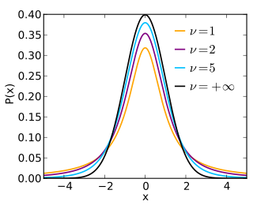

Distribució T per diferents graus de llibertat

Hem de colocar l’estadístic de contrast calculat amb les nostres dades en aquesta distribució i mirar a les taules les probabilitats de que el valor estigui on és, és a dir, l’àrea sota la corba més cap a fora del nostre punt (els valors més extrems del nostre punt).

La fórmula per calcular l’estadístic de contrast en aquest cas és:

$$t =
\frac{\bar{x_A}-\bar{x_B}}{\sqrt{\frac{s_{conj}}{n_A}+\frac{s_{conj}}{n_B}}}$$

Que, amb les nostres dades, dóna:
$$t =
1.856$$

Busquem a les taules la probabilitat de que això es doni, amb graus de llibertat:
$$n_A+n_b-2 = 38$$

[Taula de T](https://www.statisticshowto.datasciencecentral.com/tables/t-distribution-table/)

Veiem que les probabilitats estan entre el 2.5 i el 5%, així que concloem que sí que podem abandonar la hipòtesi nul·la i acceptar que la pastilla baixa el colesterol.

En el segon cas, la tipificació és molt més senzilla:

$$z = \frac{x-\mu}{\sigma}$$

Que, en el nostre cas val:
$$z= 2.5$$

En aquest cas mirem a les taules de la distribució normal:

[Taula de Z](http://www.z-table.com/)

Per tant veiem que la probabilitat de que entri algú de 195cm o més és del 0,62%.

Per tant, veiem que sempre és el mateix:

Això ho condensem amb els *tests d’hipòtesi*, que fan tot aquest procediment d’una tirada:

Test d’hipòtesi <-> Mostra -> Distribució -> Posició en la distribució -> Probabilitat (p)

Ara la pregunta és: quin test d’hipòtesi he de fer servir?

### Tests d’hipòtesi

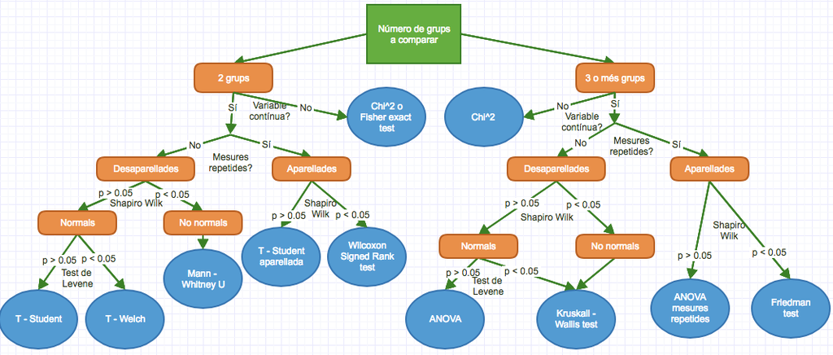

Diagrama per escollir el test d’hipòesis que t’interessa

I taules!

[output not shown]

# Contrastos d’hipòtesis

## Introducció

1. Volem verificar si es compleix una hipòtesis sobre un conjunt de dades.
- Hipòtesis nul·la (H$_0$):
- Hipòtesis alternativa (H$_1$):
2. Estadístic de contrast (sota la H$_0$)
3. Valor observat del estadístic de contrast.
4. Valor p: Si la H$_0$ és certa, probabilitat d’observar una diferència/ un valor igual o més extrem.

## Dades de mostra

Per mostrar els contrastos d’hipòtesi utilitzarem el següent conjunt:

```r
fitxer <- "data/pulse2sa.sav"
dades_pulse <- read_sav(fitxer)
head(dades_pulse)
```

```
## # A tibble: 6 × 12
##      ID HEIGHT WEIGHT   AGE GENDER  SMOKES ALCOHOL EXERCISE TRT    PULSE1 PULSE2
##   <dbl>  <dbl>  <dbl> <dbl> <dbl+l> <dbl+> <dbl+l> <dbl+lb> <dbl+>  <dbl>  <dbl>
## 1     1    173     57    18 2 [Don… 2 [Si] 1 [No]  2 [Mode… 2 [Si]     86     88
## 2     2    179     58    19 2 [Don… 2 [Si] 1 [No]  2 [Mode… 1 [No]     82    150
## 3     3    167     62    18 2 [Don… 2 [Si] 1 [No]  1 [Gens] 1 [No]     96    176
## 4     4    195     84    18 1 [Hom… 2 [Si] 1 [No]  1 [Gens] 2 [Si]     71     73
## 5     5    173     64    18 2 [Don… 2 [Si] 1 [No]  3 [Inte… 2 [Si]     90     88
## 6     6    184     74    22 1 [Hom… 2 [Si] 1 [No]  3 [Inte… 1 [No]     78    141
## # ℹ 1 more variable: YEAR <dbl>
```

# Constrastar la normalitat

## Test de shapiro-wilk:

H$_0$: variable ~ distribució normal

H$_1$: variable no segueix distribució normal

La funció en R és:

```r
shapiro.test(x)
```

On x és un vector numèric.

Exemple:

```r
shapiro.test(dades_pulse$HEIGHT)
```

```
##
##  Shapiro-Wilk normality test
##
## data:  dades_pulse$HEIGHT
## W = 0.98817, p-value = 0.4705
```

## Comprovació visual

- És interessant fer gràfics per comprovar la normalitat de forma visual.
- Serveix, per exemple, per assegurar-nos d’haver fet bé el test de Shapiro.
- Hi ha principalment dos gràfics que ens ajudaran a veure la normalitat.
- Histograma: dibuixa les freqüències agrupades segons els resultats.
- Dibuixem l’histograma amb la funció hist().
- qqplot: dibuixa els quantils de la mostra en comparació amb quantils teòrics que segueixin una distribució normal.
- Dibuixem el qqplot amb la funció qqnorm() i qqline() opcionalment per afegir una línia que marca la normal.

## Comprovació visual: histograma

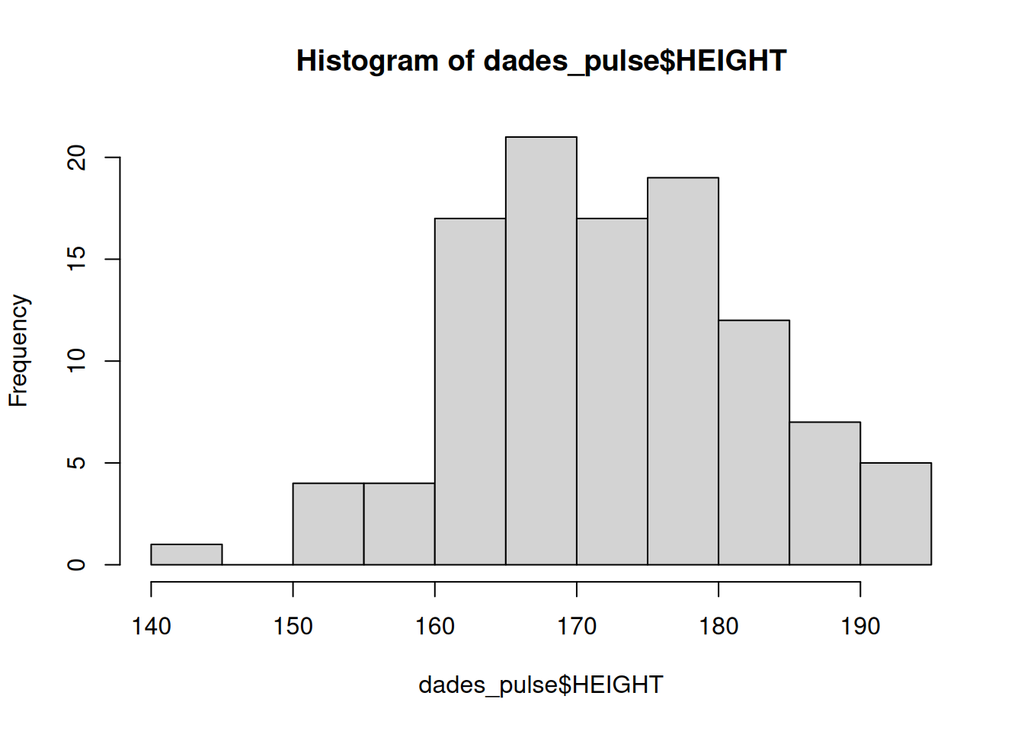

```r
# Versió base R
hist(dades_pulse$HEIGHT)
```

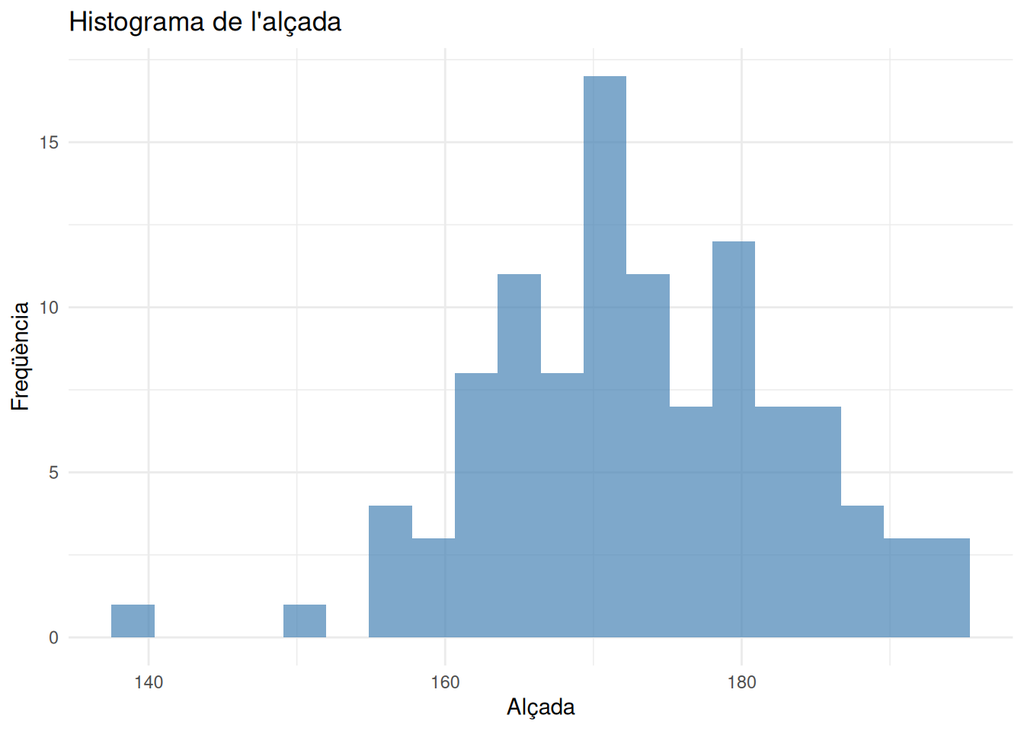

```r
# Versió tidyverse amb ggplot2
dades_pulse |>
  ggplot(aes(x = HEIGHT)) +
  geom_histogram(bins = 20, fill = "steelblue", alpha = 0.7) +
  labs(
    title = "Histograma de l'alçada",
    x = "Alçada",
    y = "Freqüència"
  ) +
  theme_minimal()
```

## Comprovació visual: qqplot

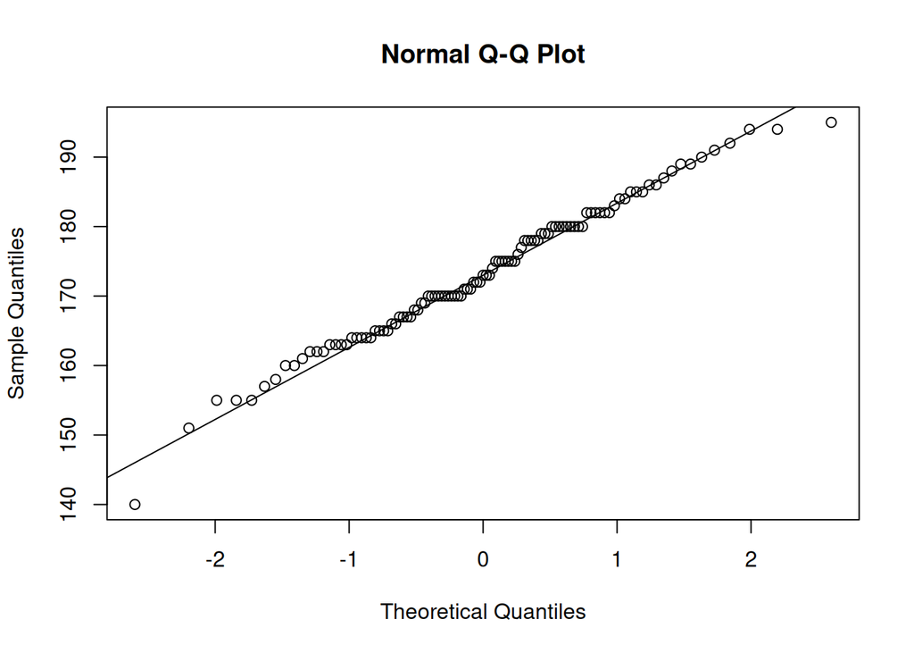

```r
# Versió base R
qqnorm(dades_pulse$HEIGHT) # Dibuixa els punts
qqline(dades_pulse$HEIGHT) # Dibuixa una línia que marca la normal
```

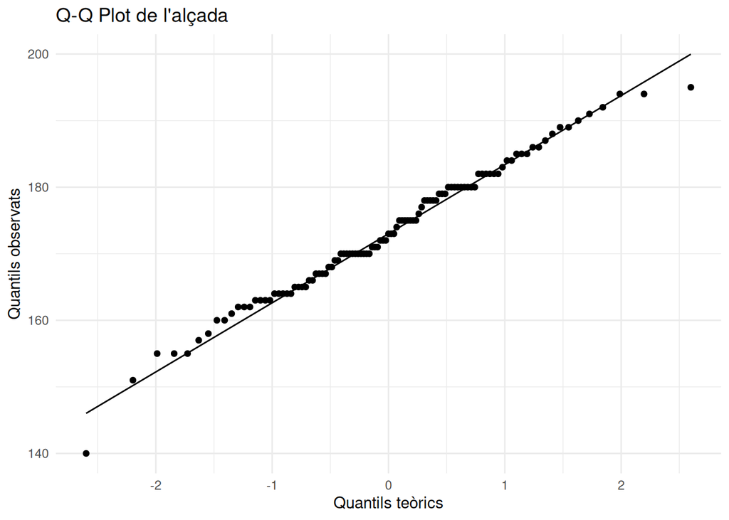

```r
# Versió tidyverse amb ggplot2
dades_pulse |>
  ggplot(aes(sample = HEIGHT)) +
  geom_qq() +
  geom_qq_line() +
  labs(
    title = "Q-Q Plot de l'alçada",
    x = "Quantils teòrics",
    y = "Quantils observats"
  ) +
  theme_minimal()
```

# Comparació de mitjanes

## Test - T

- Respecte una mitjana ($\mu$) de referència

H$_0$: $\mu$= $\mu_0$

H$_1$: $\mu$ $\neq$ $\mu_0$

La funció en R és:

```r
t.test(x,          #  vector numèric
       y = NULL,   #  segon vector numèric, en cas de que en vulguem comparar 2
       alternative = c("two.sided", "less", "greater"), #  T d'Student bivariada o
       # univariada per l'esquerra o per la dreta
       mu = 0,     #  mitjana real, en cas de que vulguem comparar un vector x
       # amb una mitjana donada
       paired = FALSE, #  dades aparellades
       var.equal = FALSE, #  homogeneïtat de variàncies (per defecte considera que
       # les variàncies NO són homogènies i fa el test de Welch)
       conf.level = 0.95, #  nivell de confiança
       ... #  altres arguments
       )
```

## Comparació de mitjanes

També es pot donar en forma de funció:

```r
t.test(x ~ y ,  #  x és un vector numèric i y categòric
       data, #  el dataframe del qual traiem les dades
       ... #  els mateixos arguments que abans
       )
```

Exemple:

- Comoparar un conjunt amb una mitjana poblacional coneguda.

```r
t.test(dades_pulse$WEIGHT, mu = 70)
```

```
##
##  One Sample t-test
##
## data:  dades_pulse$WEIGHT
## t = -2.2582, df = 106, p-value = 0.02598
## alternative hypothesis: true mean is not equal to 70
## 95 percent confidence interval:
##  63.90108 69.60360
## sample estimates:
## mean of x
##  66.75234
```

## Interval de confiança

- La funció t.test, així com les que veurem a continuació, també ens donen l’interval de confiança.
- En l’exmeple anterior amb una confiança del 95% podem dir que la mitjana es troba entre 63.9 i 69.6.
- Veiem que correspon amb la p, ja que el 70 no està dins l’interval i per tant la mitjana és significativamet diferent a aquest valor.
- En els propers exemples fixeu-vos que sempre rebem un interval de confiança d’allò que estem analitzant.

Exemple:

Test-t: comparació de dues mitjanes amb variàncies heterogènies

H$_0$: $\mu$= $\mu_0$ H$_0$: $\mu$$\leq$ $\mu_0$

H$_1$: $\mu$ $\neq$ $\mu_0$ H$_1$: $\mu$ > $\mu_0$

```r
t.test(WEIGHT ~ TRT, dades_pulse)
```

```
##
##  Welch Two Sample t-test
##
## data:  WEIGHT by TRT
## t = 0.25863, df = 96.474, p-value = 0.7965
## alternative hypothesis: true difference in means between group 1 and group 2 is not equal to 0
## 95 percent confidence interval:
##  -5.028677  6.535487
## sample estimates:
## mean in group 1 mean in group 2
##        67.18889        66.43548
```

Exemple:

Test-t: comaparació de dues mitjanes amb variàncies homogenies

H$_0$: $\mu$= $\mu_0$ H$_0$: $\mu$$\leq$ $\mu_0$

H$_1$: $\mu$ $\neq$ $\mu_0$ H$_1$: $\mu$ > $\mu_0$

```r
t.test(HEIGHT ~ TRT, dades_pulse, var.equal = TRUE)
```

```
##
##  Two Sample t-test
##
## data:  HEIGHT by TRT
## t = 0.072909, df = 105, p-value = 0.942
## alternative hypothesis: true difference in means between group 1 and group 2 is not equal to 0
## 95 percent confidence interval:
##  -3.821415  4.113171
## sample estimates:
## mean in group 1 mean in group 2
##        173.3556        173.2097
```

Dades aparellades:

H$_0$: $\mu_1$ - $\mu_2$ = 0

H$_1$: $\mu_2$ - $\mu_2$ $\neq$ 0

```r
t.test(dades_pulse$PULSE1, dades_pulse$PULSE2, paired = TRUE) # dades aparellades
```

```
##
##  Paired t-test
##
## data:  dades_pulse$PULSE1 and dades_pulse$PULSE2
## t = -7.3572, df = 106, p-value = 4.175e-11
## alternative hypothesis: true mean difference is not equal to 0
## 95 percent confidence interval:
##  -26.71835 -15.37510
## sample estimates:
## mean difference
##       -21.04673
```

# Comparació de variàncies

H$_0$: $\sigma_1$ / $\sigma_2$ = 1

H$_1$: $\sigma_1$/ $\sigma_2$ $\neq$ 1

```r
var.test(x, y, #  els dos vectors a comparar
         ratio = 1, #  valor esperat per l'hipòtesi 0 de la relació entre variàncies
         alternative = c("two.sided", "less", "greater"), #  bivariat o univariat
         conf.level = 0.95, #  nivell de confiança
         ... #  altres arguments
         )
```

Exemple:

```r
var.test(WEIGHT ~ TRT, dades_pulse)
```

```
##
##  F test to compare two variances
##
## data:  WEIGHT by TRT
## F = 0.94551, num df = 44, denom df = 61, p-value = 0.8541
## alternative hypothesis: true ratio of variances is not equal to 1
## 95 percent confidence interval:
##  0.5499249 1.6670453
## sample estimates:
## ratio of variances
##          0.9455104
```

# Comparació de medianes (no paramètric)

## Wilcoxon-Mann-Whitney test

H$_0$: Mediana$_1$ = Mediana$_2$

H$_1$: Mediana$_1$ $\neq$ Mediana$_2$

La funció en R és:

```r
wilcox.test(x,          #  vector numèric
            y = NULL,   #  segon vector numèric, en cas de que en vulguem comparar 2
            alternative = c("two.sided", "less", "greater"), #  T d'Student bivariada o univariada per l'esquerra o per la dreta
            mu = 0,     #  mitjana real, en cas de que vulguem comparar un vector x amb una mitjana donada
           paired = FALSE, #  dades aparellades
           var.equal = FALSE, #  homogeneïtat de variàncies (per defecte fa considera que les variàncies NO són homogènies i fa el test de Welch)
           conf.level = 0.95, #  nivell de confiança
           ... #  altres arguments
           )
```

També es pot donar en forma de funció:

```r
wilcox.test(x ~ y ,          #  x és un vector numèric i y categòric
            data, #  el dataframe del qual traiem les dades
            ... #  els mateixos arguments que abans
            )
```

Exemple

```r
wilcox.test(PULSE1 ~ TRT, data = dades_pulse)
```

```
##
##  Wilcoxon rank sum test with continuity correction
##
## data:  PULSE1 by TRT
## W = 1366, p-value = 0.8571
## alternative hypothesis: true location shift is not equal to 0
```

Dades aparellades

y = x1 - x2

H$_0$: Mediana$_y$ = 0

H$_1$: Mediana$_y$ $\neq$ 0

```r
wilcox.test(dades_pulse$PULSE1, dades_pulse$PULSE2, paired = TRUE)
```

```
##
##  Wilcoxon signed rank test with continuity correction
##
## data:  dades_pulse$PULSE1 and dades_pulse$PULSE2
## V = 971, p-value = 1.486e-07
## alternative hypothesis: true location shift is not equal to 0
```

# Taules de contingència

## Chi quadrat

H$_0$: Variables independents

H$_1$:Variables no independents

Per comparar dues variables categòriques fem servir el test de Chi^2, que en R és:

```r
chisq.test(x, #  vector 1 a comparar
           y = NULL, #  vector 2 a comparar
           simulate.p.value = FALSE, #  simular el valor p,
           # s'utilitza en mostres petites
           ... #  altres arguments
           )
```

Exemple:

```r
chisq.test(dades_pulse$SMOKES, dades_pulse$TRT)
```

```
##
##  Pearson's Chi-squared test with Yates' continuity correction
##
## data:  dades_pulse$SMOKES and dades_pulse$TRT
## X-squared = 0.52734, df = 1, p-value = 0.4677
```

Test exacte de Fisher en R:

```r
fisher.test(x, y = NULL, #  els dos vectors categòrics a comparar
            alternative = "two.sided", #  bivariat o univariat
            conf.int = TRUE,  #  volem que mostri els intervals de confiança?
            conf.level = 0.95,   #  nivell de confiança
            simulate.p.value = FALSE, #  simular el valor p, usat en mostres petites
            ... #  altres arguments
            )
```

Exemple:

```r
fisher.test(dades_pulse$SMOKES, dades_pulse$TRT)
```

```
##
##  Fisher's Exact Test for Count Data
##
## data:  dades_pulse$SMOKES and dades_pulse$TRT
## p-value = 0.351
## alternative hypothesis: true odds ratio is not equal to 1
## 95 percent confidence interval:
##  0.07815957 2.18123509
## sample estimates:
## odds ratio
##  0.4852291
```

Funció útil: CrossTable (paquet gmodels)

```r
CrossTable(dades_pulse$SMOKES, dades_pulse$TRT, chisq = TRUE, fisher = TRUE)
```

```
##
##
##    Cell Contents
## |-------------------------|
## |                       N |
## | Chi-square contribution |
## |           N / Row Total |
## |           N / Col Total |
## |         N / Table Total |
## |-------------------------|
##
##
## Total Observations in Table:  107
##
##
##                    | dades_pulse$TRT
## dades_pulse$SMOKES |         1 |         2 | Row Total |
## -------------------|-----------|-----------|-----------|
##                  1 |         3 |         8 |        11 |
##                    |     0.572 |     0.415 |           |
##                    |     0.273 |     0.727 |     0.103 |
##                    |     0.067 |     0.129 |           |
##                    |     0.028 |     0.075 |           |
## -------------------|-----------|-----------|-----------|
##                  2 |        42 |        54 |        96 |
##                    |     0.065 |     0.048 |           |
##                    |     0.438 |     0.562 |     0.897 |
##                    |     0.933 |     0.871 |           |
##                    |     0.393 |     0.505 |           |
## -------------------|-----------|-----------|-----------|
##       Column Total |        45 |        62 |       107 |
##                    |     0.421 |     0.579 |           |
## -------------------|-----------|-----------|-----------|
##
##
## Statistics for All Table Factors
##
##
## Pearson's Chi-squared test
## ------------------------------------------------------------
```

[output cut: 10 more lines]

```
##
## Alternative hypothesis: true odds ratio is not equal to 1
## p =  0.3510073
## 95% confidence interval:  0.07815957 2.181235
##
## Alternative hypothesis: true odds ratio is less than 1
## p =  0.2369168
## 95% confidence interval:  0 1.791648
##
## Alternative hypothesis: true odds ratio is greater than 1
## p =  0.9179263
## 95% confidence interval:  0.104765 Inf
##
##
##
```

## Exemples:

Anem a veure com s’utilitzen. Seguim amb el fitxer de malalties del fetge.

Quines dades teníem?

```r
liver <- read_csv('data/indian_liver_patient.csv')
```

```r
head(liver)
```

```
## # A tibble: 6 × 11
##     Age Gender Total_Bilirubin Direct_Bilirubin Alkaline_Phosphotase
##   <dbl> <chr>            <dbl>            <dbl>                <dbl>
## 1    65 Female             0.7              0.1                  187
## 2    62 Male              10.9              5.5                  699
## 3    62 Male               7.3              4.1                  490
## 4    58 Male               1                0.4                  182
## 5    72 Male               3.9              2                    195
## 6    46 Male               1.8              0.7                  208
## # ℹ 6 more variables: Alamine_Aminotransferase <dbl>,
## #   Aspartate_Aminotransferase <dbl>, Total_Protiens <dbl>, Albumin <dbl>,
## #   Albumin_and_Globulin_Ratio <dbl>, Dataset <dbl>
```

```r
glimpse(liver)
```

```
## Rows: 583
## Columns: 11
## $ Age                        <dbl> 65, 62, 62, 58, 72, 46, 26, 29, 17, 55, 57,…
## $ Gender                     <chr> "Female", "Male", "Male", "Male", "Male", "…
## $ Total_Bilirubin            <dbl> 0.7, 10.9, 7.3, 1.0, 3.9, 1.8, 0.9, 0.9, 0.…
## $ Direct_Bilirubin           <dbl> 0.1, 5.5, 4.1, 0.4, 2.0, 0.7, 0.2, 0.3, 0.3…
## $ Alkaline_Phosphotase       <dbl> 187, 699, 490, 182, 195, 208, 154, 202, 202…
## $ Alamine_Aminotransferase   <dbl> 16, 64, 60, 14, 27, 19, 16, 14, 22, 53, 51,…
## $ Aspartate_Aminotransferase <dbl> 18, 100, 68, 20, 59, 14, 12, 11, 19, 58, 59…
## $ Total_Protiens             <dbl> 6.8, 7.5, 7.0, 6.8, 7.3, 7.6, 7.0, 6.7, 7.4…
## $ Albumin                    <dbl> 3.3, 3.2, 3.3, 3.4, 2.4, 4.4, 3.5, 3.6, 4.1…
## $ Albumin_and_Globulin_Ratio <dbl> 0.90, 0.74, 0.89, 1.00, 0.40, 1.30, 1.00, 1…
## $ Dataset                    <dbl> 1, 1, 1, 1, 1, 1, 1, 1, 2, 1, 1, 1, 2, 1, 1…
```

```r
# Canviem el nom i formategem la variable d'interès
liver <- liver |>
  rename(Malaltia = Dataset) |>
  mutate(
    Malaltia = case_when(
      Malaltia == 1 ~ "No malalt",
      Malaltia == 2 ~ "Malalt"
    ) |> fct_inorder(),
    Gender = as_factor(Gender)
  )
```

Comprovem que ho hem fet bé:

```r
glimpse(liver)
```

```
## Rows: 583
## Columns: 11
## $ Age                        <dbl> 65, 62, 62, 58, 72, 46, 26, 29, 17, 55, 57,…
## $ Gender                     <fct> Female, Male, Male, Male, Male, Male, Femal…
## $ Total_Bilirubin            <dbl> 0.7, 10.9, 7.3, 1.0, 3.9, 1.8, 0.9, 0.9, 0.…
## $ Direct_Bilirubin           <dbl> 0.1, 5.5, 4.1, 0.4, 2.0, 0.7, 0.2, 0.3, 0.3…
## $ Alkaline_Phosphotase       <dbl> 187, 699, 490, 182, 195, 208, 154, 202, 202…
## $ Alamine_Aminotransferase   <dbl> 16, 64, 60, 14, 27, 19, 16, 14, 22, 53, 51,…
## $ Aspartate_Aminotransferase <dbl> 18, 100, 68, 20, 59, 14, 12, 11, 19, 58, 59…
## $ Total_Protiens             <dbl> 6.8, 7.5, 7.0, 6.8, 7.3, 7.6, 7.0, 6.7, 7.4…
## $ Albumin                    <dbl> 3.3, 3.2, 3.3, 3.4, 2.4, 4.4, 3.5, 3.6, 4.1…
## $ Albumin_and_Globulin_Ratio <dbl> 0.90, 0.74, 0.89, 1.00, 0.40, 1.30, 1.00, 1…
## $ Malaltia                   <fct> No malalt, No malalt, No malalt, No malalt,…
```

Primer mirem si segueix una distribució normal:

```r
shapiro.test(liver$Total_Protiens)
```

```
##
##  Shapiro-Wilk normality test
##
## data:  liver$Total_Protiens
## W = 0.99217, p-value = 0.003702
```

No té una distribució normal, per tant hem de fer una U de Mann - Whitney:

```r
wilcox.test(Total_Protiens ~ Gender, data = liver)
```

```
##
##  Wilcoxon rank sum test with continuity correction
##
## data:  Total_Protiens by Gender
## W = 35138, p-value = 0.02832
## alternative hypothesis: true location shift is not equal to 0
```

Això és veritat?

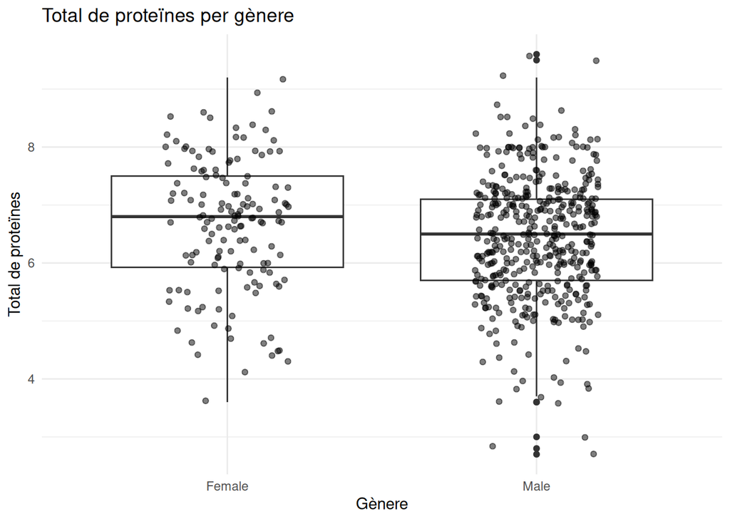

```r
liver |>
  ggplot(aes(x = Gender, y = Total_Protiens)) +
  geom_boxplot() +
  geom_jitter(width = 0.2, alpha = 0.5) +
  labs(
    title = "Total de proteïnes per gènere",
    x = "Gènere",
    y = "Total de proteïnes"
  ) +
  theme_minimal()
```

Visualment sembla que potser sí, tot i que no està del tot clar.

Què passa si assumim normalitat?

```r
t.test(Total_Protiens ~ Gender, data = liver)
```

```
##
##  Welch Two Sample t-test
##
## data:  Total_Protiens by Gender
## t = 2.0878, df = 226.51, p-value = 0.03793
## alternative hypothesis: true difference in means between group Female and group Male is not equal to 0
## 95 percent confidence interval:
##  0.0126510 0.4377019
## sample estimates:
## mean in group Female   mean in group Male
##             6.653521             6.428345
```

Gairebé el mateix!

Provem amb una altra variable:

```r
wilcox.test(Albumin_and_Globulin_Ratio ~ Gender, data = liver)
```

```
##
##  Wilcoxon rank sum test with continuity correction
##
## data:  Albumin_and_Globulin_Ratio by Gender
## W = 31090, p-value = 0.8337
## alternative hypothesis: true location shift is not equal to 0
```

A veure?

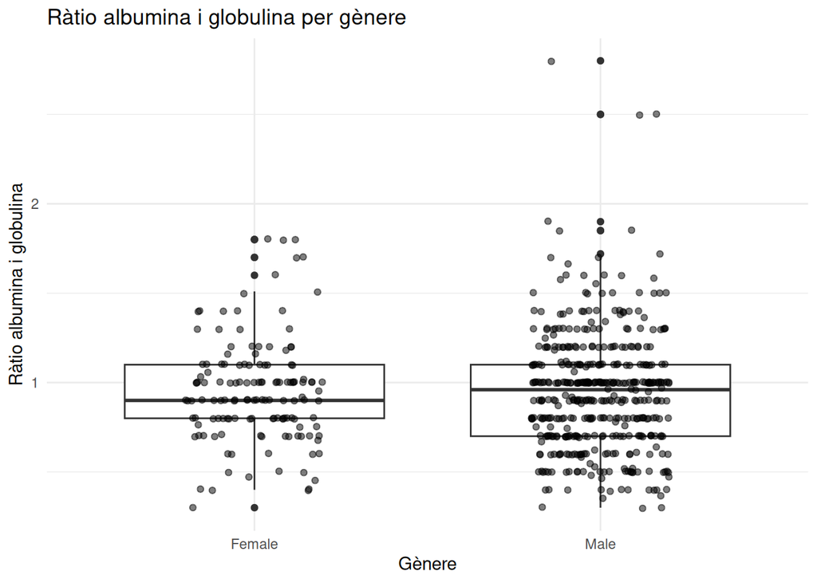

```r
liver |>
  ggplot(aes(x = Gender, y = Albumin_and_Globulin_Ratio)) +
  geom_boxplot() +
  geom_jitter(width = 0.2, alpha = 0.5) +
  labs(
    title = "Ràtio albumina i globulina per gènere",
    x = "Gènere",
    y = "Ràtio albumina i globulina"
  ) +
  theme_minimal()
```

Ara volem veure si estadísticament la malaltia afecta més a homes o a dones:

```r
# Crear taula de contingència amb tidyverse
liver |>
  count(Gender, Malaltia) |>
  pivot_wider(names_from = Malaltia, values_from = n)
```

```
## # A tibble: 2 × 3
##   Gender `No malalt` Malalt
##   <fct>        <int>  <int>
## 1 Female          92     50
## 2 Male           324    117
```

```r
# Test chi-quadrat
chisq.test(liver$Gender, liver$Malaltia)
```

```
##
##  Pearson's Chi-squared test with Yates' continuity correction
##
## data:  liver$Gender and liver$Malaltia
## X-squared = 3.5466, df = 1, p-value = 0.05967
```

Justet però sembla que no!

Ho podem fer també amb la nostra taula creuada amb tot integrat:

```r
CrossTable(liver$Gender, liver$Malaltia, chisq = TRUE, fisher = TRUE)
```

```
##
##
##    Cell Contents
## |-------------------------|
## |                       N |
## | Chi-square contribution |
## |           N / Row Total |
## |           N / Col Total |
## |         N / Table Total |
## |-------------------------|
##
##
## Total Observations in Table:  583
##
##
##              | liver$Malaltia
## liver$Gender | No malalt |    Malalt | Row Total |
## -------------|-----------|-----------|-----------|
##       Female |        92 |        50 |       142 |
##              |     0.858 |     2.137 |           |
##              |     0.648 |     0.352 |     0.244 |
##              |     0.221 |     0.299 |           |
##              |     0.158 |     0.086 |           |
## -------------|-----------|-----------|-----------|
##         Male |       324 |       117 |       441 |
##              |     0.276 |     0.688 |           |
##              |     0.735 |     0.265 |     0.756 |
##              |     0.779 |     0.701 |           |
##              |     0.556 |     0.201 |           |
## -------------|-----------|-----------|-----------|
## Column Total |       416 |       167 |       583 |
##              |     0.714 |     0.286 |           |
## -------------|-----------|-----------|-----------|
##
##
## Statistics for All Table Factors
##
##
## Pearson's Chi-squared test
## ------------------------------------------------------------
```

[output cut: 10 more lines]

```
##
## Alternative hypothesis: true odds ratio is not equal to 1
## p =  0.05460083
## 95% confidence interval:  0.4360828 1.019862
##
## Alternative hypothesis: true odds ratio is less than 1
## p =  0.03100023
## 95% confidence interval:  0 0.9546097
##
## Alternative hypothesis: true odds ratio is greater than 1
## p =  0.9809783
## 95% confidence interval:  0.464933 Inf
##
##
##
```

## Correlacions

I les Albumines i els Total_Protiens estan correlacionats?

```r
cor.test(liver$Albumin, liver$Total_Protiens, method = "spearman")
```

```
##
##  Spearman's rank correlation rho
##
## data:  liver$Albumin and liver$Total_Protiens
## S = 7296170, p-value < 2.2e-16
## alternative hypothesis: true rho is not equal to 0
## sample estimates:
##       rho
## 0.7790765
```

Clarament sí! Anem a veure-ho:

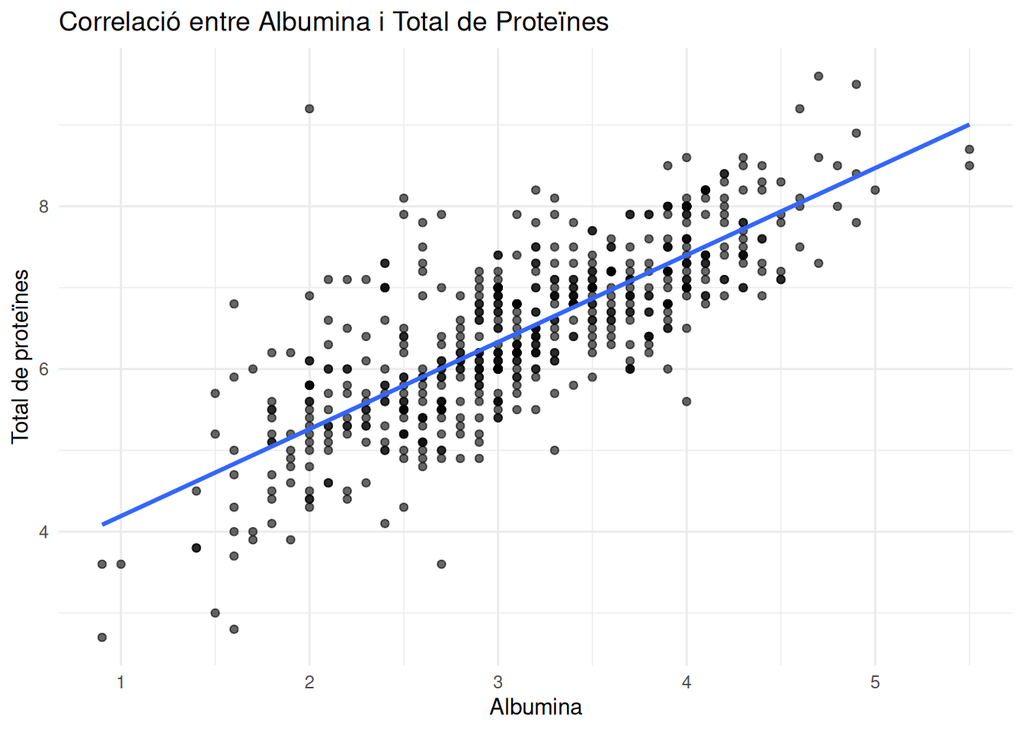

```r
liver |>
  ggplot(aes(x = Albumin, y = Total_Protiens)) +
  geom_point(alpha = 0.6) +
  geom_smooth(method = "lm", se = FALSE) +
  labs(
    title = "Correlació entre Albumina i Total de Proteïnes",
    x = "Albumina",
    y = "Total de proteïnes"
  ) +
  theme_minimal()
```

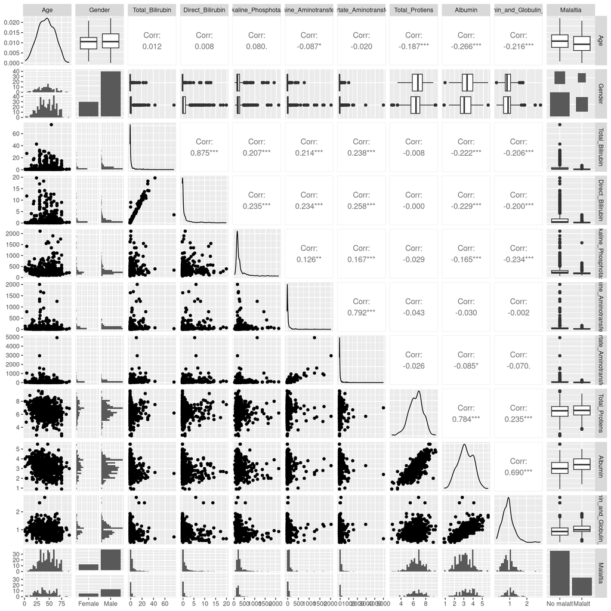

```r
ggpairs(liver)
```

Veient aquest gràfic, ens trobem que hi ha moltes mesures que estan molt escorades a l’esquerra; això passa molt sovint en medicina i s’ha de mirar d’arreglar. Això se sol fer traient el logaritme de la variable, en R és molt senzill:

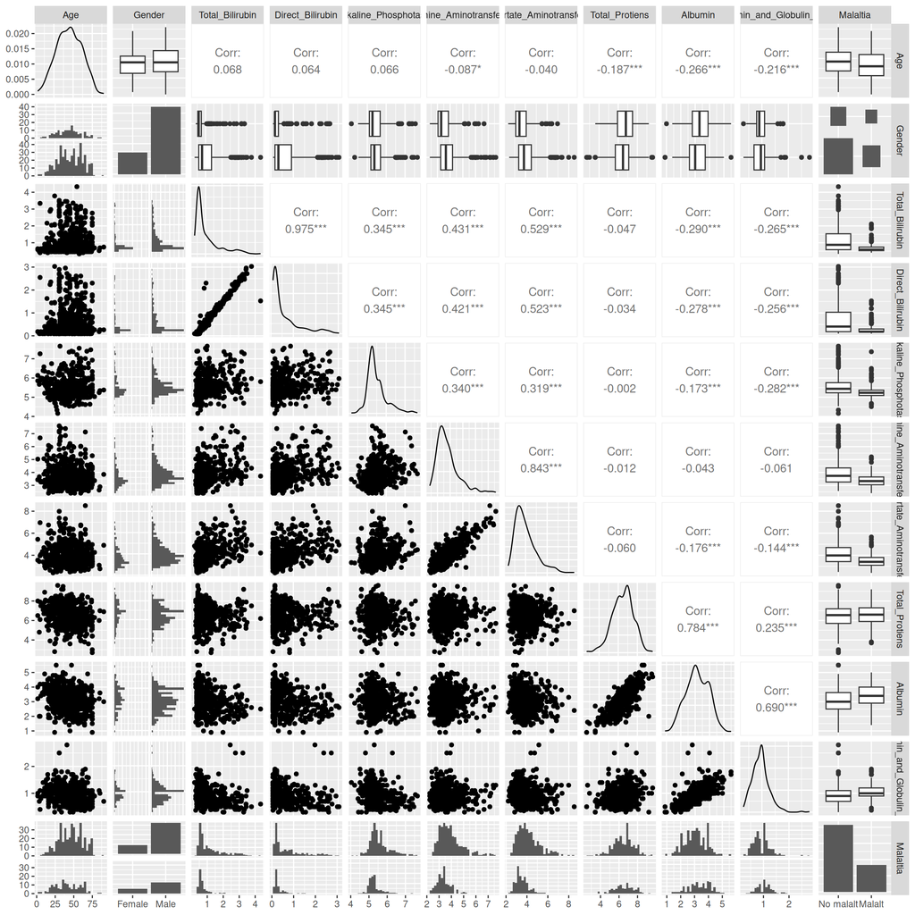

```r
liver |>
  mutate(
    across(
      c(
        Total_Bilirubin,
        Direct_Bilirubin,
        Alkaline_Phosphotase,
        Alamine_Aminotransferase,
        Aspartate_Aminotransferase
      ),
      log1p # log1p(x) = log(x + 1)
    )
  ) |>
  ggpairs()
```